# NumPy

## 郭耀仁

## 課程內容

- 我們的問題
- 第一次使用 ndarray
- 建立 ndarray 的方法
- 資料類型
- 選擇 ndarray 的元素
- ndarray 的運算
- 常用屬性與方法

## 我們的問題

- 我想一次把這幾個距離從公里換算成英里

```
km_list = [3, 5, 10, 21, 42.195]
km_to_mile = 0.62137
```

## 我們的問題（2）

- Python 的 list 無法使用 **element-wise** 運算

```
km_list = [3, 5, 10, 21, 42.195]
print km_list * 0.62137
```

## 我們的問題（3）

- 在不引用套件的情況下我們可以使用`迴圈`來處理

```python
km_list = [3, 5, 10, 21, 42.195]
mile_list = []

for km in km_list:
    mile_list.append(km * 0.62137)

for i, j in zip(km_list, mile_list):
    print "%.2f km: %.2f mile" % (i, j)
```

```
3.00 km: 1.86 mile
5.00 km: 3.11 mile
10.00 km: 6.21 mile
21.00 km: 13.05 mile
42.20 km: 26.22 mile
```

## 我們的問題（4）

- 或者使用 `map()` 和 lambda 函數一起處理

```python
km_list = [3, 5, 10, 21, 42.195]
mile_list = map(lambda x: x * 0.621371192, km_list)
for i, j in zip(km_list, mile_list):
    print "%.2f km: %.2f mile" % (i, j)
```

```
3.00 km: 1.86 mile
5.00 km: 3.11 mile
10.00 km: 6.21 mile
21.00 km: 13.05 mile
42.20 km: 26.22 mile
```

## 我們的問題（5）

- 這樣處理會不會覺得太麻煩呢？
- R 語言使用者表示：

[figure not shown]

## 第一次使用 ndarray

```python
import numpy as np # 引入 numpy 套件

km_list = [3, 5, 10, 21, 42.195]
km_array = np.array(km_list)
print(type(km_array))
print "\n"
mile_array = km_array * 0.62137
for i, j in zip(km_list, mile_list):
    print "%.2f km: %.2f mile" % (i, j)
```

```
<type 'numpy.ndarray'>


3.00 km: 1.86 mile
5.00 km: 3.11 mile
10.00 km: 6.21 mile
21.00 km: 13.05 mile
42.20 km: 26.22 mile
```

## 第一次使用 ndarray（2）

- 練習計算這五個人的 [BMI](https://zh.wikipedia.org/wiki/身高體重指數)

```
heights = [173, 168, 171, 189, 179]
weights = [65.4, 59.2, 63.6, 88.4, 68.7]
```

## 建立 ndarray 的方法

| 方法 | 描述 |
| --- | --- |
| `numpy.array()` | 基本的建立 |
| `numpy.arange()` | 類似 `range()` |
| `numpy.linspace()` | 建立等距切分的陣列 |
| `numpy.empty()` | 建立上未初始化的陣列 |
| `numpy.ones()` | 建立都是 1 的陣列 |
| `numpy.zeros()` | 建立都是 0 的陣列 |
| `numpy.eye()` | 建立單位矩陣 |
| `numpy.random.rand()` | 建立符合均勻分布的陣列 |
| `numpy.random.randn()` | 建立符合常態分布的陣列 |
| `numpy.random.randint()` | 建立隨機整數的陣列 |

## 建立 ndarray 的方法（2）

- `numpy.arange()`
- 產生預設以 1 作為公差的數列

```python
import numpy as np

arr = np.arange(10)
print arr
arr = np.arange(1, 10)
print arr
arr = np.arange(1, 10, 2)
print arr
```

```
[0 1 2 3 4 5 6 7 8 9]
[1 2 3 4 5 6 7 8 9]
[1 3 5 7 9]
```

## 建立 ndarray 的方法（3）

- `numpy.linspace()`
- 產生特定個數、均等切分的數列

```python
import numpy as np

arr = np.linspace(0, 1, 10)
print arr
```

```
[ 0.          0.11111111  0.22222222  0.33333333  0.44444444  0.55555556
  0.66666667  0.77777778  0.88888889  1.        ]
```

## 建立 ndarray 的方法（4）

- `numpy.empty()`
- 建立尚未初始化的陣列
- 輸入一個數字建立一維空陣列
- 輸入 tuple 建立多維空陣列

```python
import numpy as np

arr = np.empty(5)
print arr
print "\n"
arr = np.empty((2, 3))
print arr
print "\n"
arr = np.empty((2, 3, 2))
print arr
```

```
[  4.94065646e-324   1.48219694e-323   2.47032823e-323   3.45845952e-323
   4.44659081e-323]


[[ -0.00000000e+000  -0.00000000e+000   2.17134152e-314]
 [  6.92676564e-310   6.92676564e-310  -0.00000000e+000]]


[[[ -0.00000000e+000  -0.00000000e+000]
  [  2.22664500e-314   2.18089946e-314]
  [  2.22675638e-314   2.18082436e-314]]

 [[  4.26784382e-090   0.00000000e+000]
  [  2.17920257e-314   1.45168228e-047]
  [ -3.11107752e+231   8.38731927e-309]]]
```

## 建立 ndarray 的方法（5）

- 用類似的例子練習看看 `numpy.zeros()` 與 `numpy.ones()`

## 建立 ndarray 的方法（6）

- `numpy.eye()`
- 建立單位矩陣
- 輸入 `n` 就會得到 `nxn` 的單位矩陣

```python
import numpy as np

arr = np.eye(3) # 3x3 的單位矩陣
print arr
print "\n"
arr = np.eye(5) # 5x5 的單位矩陣
print arr
```

```
[[ 1.  0.  0.]
 [ 0.  1.  0.]
 [ 0.  0.  1.]]


[[ 1.  0.  0.  0.  0.]
 [ 0.  1.  0.  0.  0.]
 [ 0.  0.  1.  0.  0.]
 [ 0.  0.  0.  1.  0.]
 [ 0.  0.  0.  0.  1.]]
```

## 建立 ndarray 的方法（7）

- `numpy.diag()`
- 建立對角矩陣

```python
import numpy as np

arr = np.diag([1, 2, 3])
print arr
```

```
[[1 0 0]
 [0 2 0]
 [0 0 3]]
```

## 建立 ndarray 的方法（8）

- `numpy.random.rand()`
- 建立符合 0~1 均勻分布的陣列

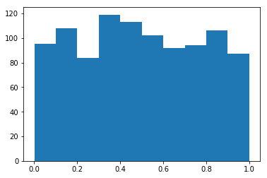

```python
import numpy as np
import matplotlib.pyplot as plt

size = 1000
arr = np.random.rand(size)
plt.hist(arr)
plt.show()
```

## 建立 ndarray 的方法（9）

- `numpy.random.randn()`
- 建立符合平均數 0，標準差 1 的常態分佈陣列

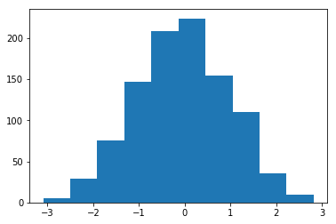

```python
import numpy as np
import matplotlib.pyplot as plt

size = 1000
arr = np.random.randn(size)
plt.hist(arr)
plt.show()
```

## 建立 ndarray 的方法（10）

- `numpy.random.randint(low, high, size)`
- 建立介於 low，high 之間的整數陣列

```python
import numpy as np

arr = np.random.randint(0, 100, size = 10)
print arr
arr = np.random.randint(0, 100, size = (2, 5))
print arr
```

```
[20 40 11 80 19 94 15 91 70 33]
[[36 50 57 55 73]
 [44 79 33 86 76]]
```

## 建立 ndarray 的方法（11）

- 練習在 `[-2, 2]` 之間均分出 50 個數字的數列
- 練習建立一個 `(5, 5)` 的單位矩陣
- 練習在隨機產出 5 個介於 100 與 200 之間整數的數列

## 資料類型

- 使用 `dtype` 屬性來指定或檢視
- 整數 `int`
  - int8
  - int16
  - int32
  - int64（預設）

```python
import numpy as np

arr = np.ones(5, dtype = 'int')
print arr
print arr.dtype # 預設是 64 位元的整數
arr = np.ones(5, dtype = 'int8') # 可以改成 8 位元的整數
print arr
print arr.dtype
```

```
[1 1 1 1 1]
int64
[1 1 1 1 1]
int8
```

## 資料類型（2）

- 使用 `dtype` 屬性來指定或檢視
- 浮點數 `float`
  - float16
  - float32
  - float64（預設）
  - float128

```python
import numpy as np

arr = np.ones(5, dtype = 'float')
print arr
print arr.dtype # 預設是 64 位元的浮點數
arr = np.ones(5, dtype = 'float16') # 可以改成 16 位元的浮點數
print arr
print arr.dtype
```

```
[ 1.  1.  1.  1.  1.]
float64
[ 1.  1.  1.  1.  1.]
float16
```

## 資料類型（3）

- 使用 `dtype` 屬性來指定或檢視
- 複數
  - complex64
  - complex128（預設）
  - complex256

```python
import numpy as np

arr = np.ones(5, dtype = 'complex')
print arr
print arr.dtype # 預設是 128 位元的複數
arr = np.ones(5, dtype = 'complex64') # 可以改成 64 位元的複數
print arr
print arr.dtype
```

```
[ 1.+0.j  1.+0.j  1.+0.j  1.+0.j  1.+0.j]
complex128
[ 1.+0.j  1.+0.j  1.+0.j  1.+0.j  1.+0.j]
complex64
```

## 資料類型（4）

- 使用 `dtype` 屬性來指定或檢視
- 布林
  - bool

```python
import numpy as np

arr = np.array((1, 0), dtype = 'bool')
print arr
print arr.dtype
```

```
[ True False]
bool
```

## 資料類型（5）

- 使用 `dtype` 屬性來指定或檢視
- 文字
  - string_（預設）
  - unicode_

```python
import numpy as np

arr = np.array(["1", "One", "True"]) # 預設為 string
print arr.dtype
arr = np.array(("1", "One", "True"), dtype = 'unicode_')
print arr.dtype
```

```
|S4
<U4
```

## 資料類型（6）

- ndarray 只能容許一個變數類型
- 同時儲存有數值，布林值，會被自動轉換為數值
- 同時儲存有數值，布林值與文字，會被自動轉換為文字

```python
import numpy as np

arr = np.array([1, True])
print arr.dtype
arr = np.array([1, True, "one"])
print arr.dtype
```

```
int64
|S21
```

## 資料類型（7）

- 除了在建立的時候使用 `dtype` 指定資料類型
- 也可以使用 `astype()` 方法轉換資料類型

```python
import numpy as np

arr = np.eye(3)
print arr.dtype
arr = arr.astype('bool')
print arr
print arr.dtype
```

```
float64
[[ True False False]
 [False  True False]
 [False False  True]]
bool
```

## 選擇 ndarray 的元素

- 用索引值選擇

```python
import numpy as np

arr = np.arange(1, 6)
print arr
print arr[0]
print arr[1]
print arr[-1]
print arr[[0, 3, 4]] # To the rescue!
```

```
[1 2 3 4 5]
1
2
5
[1 4 5]
```

## 選擇 ndarray 的元素（2）

- 用索引值選擇
- slicing `arr[startIndex: endIndex: stepValue]`

```python
import numpy as np

arr = np.arange(1, 6)
print arr[:3]
print arr[3:]
print arr[0:5:2]
```

```
[1 2 3]
[4 5]
[1 3 5]
```

## 選擇 ndarray 的元素（3）

- 多維度的 ndarray 元素選擇

```python
import numpy as np

arr = np.array(range(10)).reshape(2, 5)
print arr
print arr[1, 0]
print("\n")
arr = np.array(range(20)).reshape(2, 2, 5)
print arr
print arr[0, 1, 0]
```

```
[[0 1 2 3 4]
 [5 6 7 8 9]]
5


[[[ 0  1  2  3  4]
  [ 5  6  7  8  9]]

 [[10 11 12 13 14]
  [15 16 17 18 19]]]
5
```

## 選擇 ndarray 的元素（4）

- 用布林選擇

```python
import numpy as np

arr = np.array(range(10))
num_filter = arr < 5
print num_filter
print arr[num_filter]
```

```
[ True  True  True  True  True False False False False False]
[0 1 2 3 4]
```

## 選擇 ndarray 的元素（5）

- 練習選出未滿 20 與超過 30 的元素

```
age = [19, 21, 20, 19, 21, 17, 30, 36, 90]
```

## 選擇 ndarray 的元素（6）

- 練習從五人中選出 BMI > 21 的元素

```
heights = [173, 168, 171, 189, 179]
weights = [65.4, 59.2, 63.6, 88.4, 68.7]
```

## 選擇 ndarray 的元素（7）

- 練習使用布林選出 Matthew Perry 與 Lisa Kudrow

```
friends_stars = ["Jennifer Aniston", "Courteney Cox", "Lisa Kudrow",
"Matt LeBlanc", "Matthew Perry", "David Schwimmer"]
```

## ndarray 的運算

- 不論一維的 ndarray 與二維的 ndarray 都符合 element-wise 運算

```python
import numpy as np

arr_1 = np.arange(5)
arr_2 = np.arange(5)
print arr_1
print arr_2
print "\n"
print arr_1 * arr_2
```

```
[0 1 2 3 4]
[0 1 2 3 4]


[ 0  1  4  9 16]
```

```python
import numpy as np

arr_1 = np.arange(10).reshape(2, 5)
arr_2 = np.arange(10).reshape(2, 5)
print arr_1
print arr_2
print "\n"
print arr_1 * arr_2
```

```
[[0 1 2 3 4]
 [5 6 7 8 9]]
[[0 1 2 3 4]
 [5 6 7 8 9]]


[[ 0  1  4  9 16]
 [25 36 49 64 81]]
```

## ndarray 的運算（2）

- 二維的 ndarray 可以進行矩陣的**內積**運算
- 使用 `.dot()` 方法或 `np.dot()`

```python
import numpy as np

arr_1 = np.arange(10).reshape(2, 5)
arr_2 = np.arange(10).reshape(5, 2)
print arr_1.dot(arr_2)
print "\n"
print np.dot(arr_1, arr_2)
```

```
[[ 60  70]
 [160 195]]


[[ 60  70]
 [160 195]]
```

## ndarray 的運算（3）

- 練習計算 $u^Tv$

$$u = \begin{bmatrix} 4 \\ -4 \\ -3 \end{bmatrix}$$$$v = \begin{bmatrix} 4 \\ 2 \\ 4 \end{bmatrix}$$

## ndarray 的運算（4）

- 練習計算 $A * I$ 與 $I * A$

$$A = \begin{bmatrix} 1 & 2 & 3 \\ 4 & 5 & 6 \\ 7 & 8 & 9 \\ \end{bmatrix}$$$$I = \begin{bmatrix} 1 & 0 & 0 \\ 0 & 1 & 0 \\ 0 & 0 & 1 \\ \end{bmatrix}$$

## ndarray 的運算（5）

- 練習計算 $A * B$ 與 $B * A$

$$A = \begin{bmatrix} 1 & 2 \\ 4 & 5 \\ \end{bmatrix}$$$$B = \begin{bmatrix} 4 & 3 \\ 2 & 1 \\ \end{bmatrix}$$

## 常用屬性與方法

- 元素個數：`.size`
- 外觀：`.shape`
- 維度：`.ndim`

## 常用屬性與方法（2）

- 變形：`.reshape()`
- 轉置：`.T`
- 攤平：`.ravel()`
- 依條件取代：`.where()`

## 常用屬性與方法（3）

- 可以指定 axis
  - 相乘：`.prod()`
  - 加總：`.sum()`
  - 平均：`.mean()`

## 作業

1. 建立一個外觀 `(9, 9)` 的 ndarray 並且填入九九乘法表（hw301.py）
2. 利用 `numpy` 提供的 `.size` 屬性、`.sum()` 方法、`.mean()` 方法與 `.sqrt()` 實作[樣本標準差](https://zh.wikipedia.org/wiki/%E6%A8%99%E6%BA%96%E5%B7%AE)函數（hw302.py）

$$SD = \sqrt{\frac{1}{N-1}\sum_{i=1}^{N}(x_i - \bar{x})^2}$$

## NumPy Documentation

https://docs.scipy.org/doc/numpy-dev/user/index.html